# Итоговый проект

Группа 8

## Идея

**Тип проекта:** рекомендательный

**Данные:** объявления с сайта Циан о продаже квартир в Санкт-Петербурге (вторичный рынок жилья)

**“Личный риэлтор”** – сервис, формирующий цену, по которой пользователь может выгодно продать свою квартиру, не прибегая к услугам агента по продаже жилья. На вход принимает характеристики квартиры, а выдает предсказанную стоимость и карту с квартирами, имеющими похожие параметры. Таким образом, пользователь экономит на оценщике.

*План работы:*

1. Парсинг данных с Циан при помощи кода Python
2. Очистка данных и уточнение состава переменных
3. Получение координат квартир (посредством кода R и вручную)
4. Создание content-based рекомендательной системы
5. Создание предсказательной модели при помощи ML
6. Создание интерфейса на shiny
7. Интеграция рекомендательной системы и предсказательной модели в приложение

## Распределение ролей

1. **Алексеев Антон:** сбор и обработка данных, построение ML модели
2. **Винниченко Валерия:** обработка данных, разработка интерфейса
3. **Винниченко Вероника:** визуализация результатов, разработка интерфейса
4. **Дьячкова Алиса:** планирование исследования, разработка интерфейса
5. **Жучков Дмитрий:** сбор данных, построение рекомендательной системы

**Все члены команды:** парсинг данных, разработка сценариев тестирования, создание дневников

## Предобработка

Первым шагом стал парсинг данных с Циан, базы объявлений о продаже недвижимости, с помощью кода на Python по критериям. Было получено 18100 наблюдений по 6-ти характеристикам (адрес, цена, ближайшее метро и расстояние до него, общая информация о квартире, информация о доме и описание).

## Архитектура приложения

Для каждого параметра была создана отдельная плашка и установлены дефолтные значения для более точного предсказания и дополнительной мотивации пользователя предоставить все свои данные. Предобработка в приложении не предусмотрена, используются финальные данные. Из параметров, введенных пользователем, формируется датасет, который в последствии прикрепляется к рекомендательной системе. Данные не сохраняются. Уже обученные на обучающей выборке модели загружаются в интерфейс, что позволяет значительно ускорить появление результата путем только лишь предсказания на данных пользователя.

## Интерфейс

#### **Входные данные:**

- Количество комнат
- Общая площадь
- Жилая площадь
- Площадь кухни
- Тип ремонта квартиры
- Наличие балкона
- Вид санузла (совмещенный/раздельный)
- Количество санузлов
- Этаж
- Год постройки дома
- Тип дома
- Наличие лифта
- Район расположения
- Ближайшая станция метро
- Расстояние до метро пешком (мин)

#### **Выходные данные:**

- Предсказанный интервал цены
- Карта с рекомендацией квартир со схожими храктеристиками

#### **Скрин интерфейса:**

##### Карта с похожими квартирами

##### Предсказанная цена

[figure not shown]

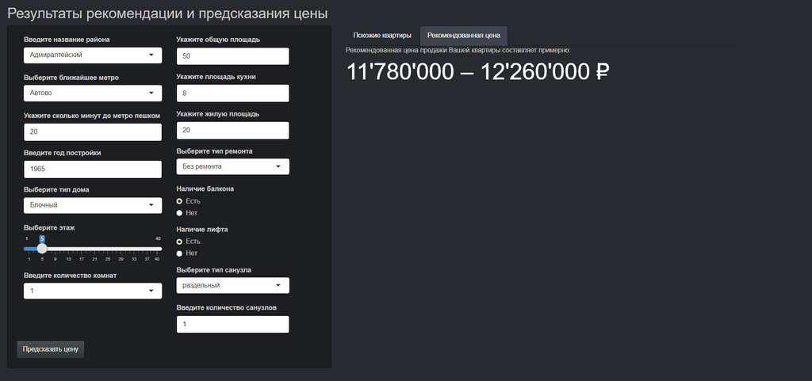

#### Код

##### Код интерфейса:

```r
# ==================ИНТЕРФЕЙС=======================
ui <- fluidPage(
  theme = shinytheme("slate"),

  titlePanel("Результаты рекомендации и предсказания цены"),

  sidebarLayout(
    sidebarPanel(
      column(6,
             selectInput(inputId = "district", label = "Введите название района",
                         selected = as.factor(levels(sort(data_final$district)[1])),
                         choices = sort(data_final$district)),

             selectInput(inputId = "subway", label = "Выберите ближайшее метро",
                         selected = as.factor(levels(sort(data_final$remont)[1])),
                         choices = sort(data_final$subway_TRUE)),

             numericInput("min_subway", label = ("Укажите сколько минут до метро пешком"),
                          min = 1, max = 40, step = 1, value = 1),

             numericInput(inputId = "year", label = "Введите год постройки",
                          min = 1746, max = 2022, value = 1965, step = 1),

             selectInput(inputId = "house_type", label = "Выберите тип дома",
                         selected = as.factor(levels(sort(data_final$housetype)[1])),
                         choices = sort(data_final$housetype)),

             sliderInput(inputId = "floor", label = "Выберите этаж",
                         min = 1, max = 40, value = 1, step = 1),

             selectInput(inputId = "rooms", label = "Введите количество комнат",
                         selected = as.factor(levels(sort(data_final$rooms)[1])),
                         choices = sort(data_final$rooms))),
      column(5,
             numericInput("num_square", label = ("Укажите общую площадь"), min = 1, value = 1, step = 1),

             numericInput("num_kitsquare", label = ("Укажите площадь кухни"), min = 1, value = 1, step = 1),

             numericInput("num_livsquare", label = ("Укажите жилую площадь"), min = 1, value = 1, step = 1),

             selectInput(inputId = "remont", label = "Выберите тип ремонта",
                         selected = as.factor(levels(sort(data_final$remont)[1])),
                         choices = sort(data_final$remont)),

             radioButtons("balcony", "Наличие балкона",
                          selected = 1,
                          c("Есть" = 1,
                            "Нет" = 0)),

             radioButtons("elevator", "Наличие лифта",
                          selected = 1,
                          c("Есть" = 1,
                            "Нет" = 0)),

             selectInput(inputId = "toilet_type", label = "Выберите тип санузла",
                         selected = as.factor(levels(sort(data_final$type_toilet)[1])),
                         choices = c("раздельный"= 1,
                                     "совмещенный"= 0)),

             numericInput(inputId = "toilet_quantity", label = "Введите количество санузлов",
                          min = 1, value = 1, step = 1)),

      actionButton("button", "Предсказать цену"),
      width = 5 # ширина инпута
    ),

    mainPanel(
      tabsetPanel(type = "tabs",
                  tabPanel("Похожие квартиры", withLoader(leafletOutput("mymap",
                                                                        width = "115%", height = 600),
                                                          type="html", loader="loader1")),

                  tabPanel("Рекомендованная цена", withLoader(htmlOutput("prediction"),
                                                              type="html", loader="loader1"))
      ),
      width = 6 # ширина аутпута

    )
  )
)

server <- function(input, output) {
  data_user <- eventReactive(input$button, {
      data_user = data.frame(id = 9999,
                 square = as.numeric(input$num_square),
                 rooms = as.character(input$rooms),
                 kitchen_square = as.numeric(input$num_kitsquare),
                 living_square = as.numeric(input$num_livsquare),
                 year = as.numeric(input$year),
                 toilet_quantity = as.numeric(input$toilet_quantity),
                 type_toilet = as.numeric(input$toilet_type),
                 if_lift = as.numeric(input$elevator),
                 if_balcony = as.numeric(input$balcony),
                 housetype = as.character(input$house_type),
                 remont = as.character(input$remont),
                 subway_dist_peshkom_TRUE = as.numeric(input$min_subway),
                 district = as.character(input$district),
                 floor = as.numeric(input$floor),
                 subway_TRUE = as.character(input$subway))
      data_user

  })

  # ==================РЕК.СИСТЕМА=======================
  recommend = reactive({
    data_final = read_excel("D:/HSE/3 курс/дата саенс/data_final.xlsx")
    data1 = data_final %>% select(id,
                                  square,
                                  rooms,
                                  district,
                                  kitchen_square,
                                  living_square,
                                  floor,
                                  year,
                                  toilet_quantity,
                                  type_toilet,
                                  if_balcony,
                                  if_lift,
                                  housetype,
                                  remont,
                                  subway_TRUE,
                                  subway_dist_peshkom_TRUE)


    data_user = data_user() #параметры, введенные пользователем
    data_cont = rbind(data1, data_user)

    data_cont$square_cat = paste(as.character(round(data_cont$square/10,0)),"square")
    data_cont$kitchen_square_cat = paste(as.character(round(data_cont$kitchen_square/10,0)),"kitchen_square")
    data_cont$living_square_cat = paste(as.character(round(data_cont$living_square/10,0)),"living_square")
    data_cont$subway_dist_cat = paste(as.character(round(data_cont$subway_dist_peshkom_TRUE/5,0)),"subway")
    data_cont$floor = paste(as.character(data_cont$floor),"floor")
    data_cont$year = as.character(data_cont$year)
    data_cont$toilet_quantity = paste(as.character(data_cont$toilet_quantity),"toilet")
    data_cont$type_toilet = paste(as.character(data_cont$type_toilet),"type_toilet")
    data_cont$if_balcony = paste(as.character(data_cont$if_balcony),"balcony")
    data_cont$if_lift = paste(as.character(data_cont$if_lift),"lift")
```

```r
    #приводим к широкому формату
    data_cont$exist = 1
    data_cont = data_cont %>% pivot_wider(names_from=rooms,values_from=exist,values_fill = 0)
    data_cont$exist = 1
    data_cont = data_cont %>% pivot_wider(names_from=floor,values_from=exist,values_fill = 0)
    data_cont$exist = 1
    data_cont = data_cont %>% pivot_wider(names_from=year,values_from=exist,values_fill = 0)
    data_cont$exist = 1
    data_cont = data_cont %>% pivot_wider(names_from=toilet_quantity,values_from=exist,names_repair = "minimal",values_fill = 0)
    data_cont$exist = 1
    data_cont = data_cont %>% pivot_wider(names_from=type_toilet,values_from=exist,values_fill = 0)
    data_cont$exist = 1
    data_cont = data_cont %>% pivot_wider(names_from=if_balcony,values_from=exist,names_repair = "minimal",values_fill = 0)
    data_cont$exist = 1
    data_cont = data_cont %>% pivot_wider(names_from=if_lift,values_from=exist,names_repair = "minimal",values_fill = 0)
    data_cont$exist = 1
    data_cont = data_cont %>% pivot_wider(names_from=district,values_from=exist,values_fill = 0)
    data_cont$exist = 1
    data_cont = data_cont %>% pivot_wider(names_from=remont,values_from=exist,values_fill = 0)
    data_cont$exist = 1
    data_cont = data_cont %>% pivot_wider(names_from=housetype,values_from=exist,values_fill = 0)
    data_cont$exist = 1
    data_cont = data_cont %>% pivot_wider(names_from=subway_TRUE,values_from=exist,values_fill = 0)
    data_cont$exist = 1
    data_cont = data_cont %>% pivot_wider(names_from=square_cat,values_from=exist,values_fill = 0)
    data_cont$exist = 1
    data_cont = data_cont %>% pivot_wider(names_from=kitchen_square_cat,values_from=exist,values_fill = 0)
    data_cont$exist = 1
    data_cont = data_cont %>% pivot_wider(names_from=living_square_cat,values_from=exist,values_fill = 0)
    data_cont$exist = 1
    data_cont = data_cont %>% pivot_wider(names_from=subway_dist_cat,values_from=exist,values_fill = 0)


    id=data_cont$id
    #удаляем ненужные переменные
    data_cont = data_cont %>% select(-c(id, square, kitchen_square, living_square, subway_dist_peshkom_TRUE))
    rownames(data_cont)=id
    a=as.matrix(data_cont)
    t=t(a)
    sim = coop::cosine(t)
    diag(sim) = 0

    sim_1 = sim
    sim_1["9999",]
    simCut = sim_1[,"9999"]
    mostSimilar = head(sort(simCut, decreasing = T), n = 5)
    a = which(simCut %in% mostSimilar, arr.ind = TRUE, useNames = T)
    a = a[1:5]
    index = arrayInd(a, .dim = dim(sim))
    result = rownames(sim)[index[,1]]
    recommend = data_final %>% filter(row.names(data_final) %in% result)
    recommend$shirota = as.numeric(recommend$shirota)
    recommend$dolgota = as.numeric(recommend$dolgota)
    recommend
  })

  #похожие квартиры
  output$mymap = renderLeaflet({
    vector1 = c(1, 0)
    vector2 = c("есть", "нет")

    recommend = recommend()
    M = leaflet(recommend) %>% setView(lng = 30.3141, lat = 59.9386, zoom = 10)
    M %>% addTiles() %>%
      addMarkers(~dolgota, ~shirota, popup = paste("<br>Адрес:", recommend$addr,
                                                   "<br>Район:", recommend$district,
                                                   "<br>Цена:", paste0(formatC(as.numeric(recommend$price), format="f", digits=0, big.mark="'"), " ₽"),
                                                   "<br>Кол-во комнат:", recommend$rooms,
                                                   "<br>Площадь (кв.м):", recommend$square,
                                                   "<br>Жилая площадь (кв.м):", recommend$living_square,
                                                   "<br>Площадь кухни (кв.м):", recommend$kitchen_square,
                                                   "<br>Этаж:", recommend$floor,
                                                   "<br>Год постройки:", recommend$year,
                                                   "<br>Тип дома:", recommend$housetype,
                                                   "<br>Балкон:", recommend$if_balcony,
                                                   "<br>Наличие лифта:", recommend$if_lift,
                                                   "<br>Кол-во санузлов:", recommend$toilet_quantity,
                                                   "<br>Тип туалета:", recommend$type_toilet,
                                                   "<br>Ремонт:", recommend$remont,
                                                   "<br>Станция метро:", recommend$subway_TRUE,
                                                   "<br>Пешком до метро (мин):", recommend$subway_dist_peshkom_TRUE),
                 label = paste0(formatC(as.numeric(recommend$price), format="f", digits=0, big.mark="'"), " ₽"))
  })

  # ==================ПРЕДСКАЗАТЕЛЬНАЯ МОДЕЛЬ=======================
  output$prediction = renderUI({
    # загружаем RDA
    load("D:/HSE/3 курс/дата саенс/model1.Rda")
    load("D:/HSE/3 курс/дата саенс/model2.Rda")
    load("D:/HSE/3 курс/дата саенс/model3.Rda")
    load("D:/HSE/3 курс/дата саенс/model4.Rda")
    load("D:/HSE/3 курс/дата саенс/model5.Rda")
    load("D:/HSE/3 курс/дата саенс/model6.Rda")
    load("D:/HSE/3 курс/дата саенс/lamb1.Rda")
    load("D:/HSE/3 курс/дата саенс/lamb2.Rda")

    data_user = data_user()

    data = data_user

    data$rooms = case_when(data_user$rooms =="1"~1, data_user$rooms =="2"~2, data_user$rooms =="3"~3, data_user$rooms == "4"~4, data_user$rooms =="5"~5, data_user$rooms == "Апартаменты-студия"~6, data_user$rooms =="Квартира свободной планировки"~7, data_user$rooms == "Многокомнатная квартира"~8, data_user$rooms == "Многокомнатные апартаменты"~9, data_user$rooms == "Студия"~10)
    data$district = case_when(data_user$district == "Адмиралтейский"~1, data_user$district == "Василеостровский"~2, data_user$district == "Выборгский"~3, data_user$district == "Калининский"~4, data_user$district == "Кировский"~5, data_user$district == "Колпинский"~6, data_user$district == "Красногвардейский"~7, data_user$district == "Красносельский"~8, data_user$district == "Кронштадтский"~9, data_user$district == "Курортный"~10, data_user$district == "Московский"~11, data_user$district == "Невский"~12, data_user$district == "Петроградский"~13, data_user$district == "Петродворцовый"~14, data_user$district == "Приморский"~15, data_user$district == "Пушкинский"~16, data_user$district == "Фрунзенский"~17, data_user$district == "Центральный"~18)
    data$housetype = case_when(data_user$housetype == "Блочный"~1, data_user$housetype == "Кирпичный"~2, data_user$housetype == "Монолитный"~3, data_user$housetype == "Панельный"~4, data_user$housetype == "Сталинский"~5)
    data$remont = case_when(data_user$remont == "Без ремонта"~1, data_user$remont == "Дизайнерский"~2, data_user$remont == "Евроремонт"~3, data_user$remont == "Косметический"~4)
    data$subway_TRUE = case_when(data_user$subway_TRUE == "Автово"~1, data_user$subway_TRUE == "Адмиралтейская"~2, data_user$subway_TRUE == "Академическая"~3, data_user$subway_TRUE == "Балтийская"~4, data_user$subway_TRUE == "Беговая"~5, data_user$subway_TRUE == "Бухарестская"~6, data_user$subway_TRUE == "Василеостровская"~7, data_user$subway_TRUE == "Владимирская"~8, data_user$subway_TRUE == "Волковская"~9, data_user$subway_TRUE == "Выборгская"~10, data_user$subway_TRUE == "Горьковская"~11, data_user$subway_TRUE == "Гостиный двор"~12, data_user$subway_TRUE == "Гражданский проспект"~13, data_user$subway_TRUE == "Девяткино"~14, data_user$subway_TRUE == "Достоевская"~15, data_user$subway_TRUE == "Дунайская"~16, data_user$subway_TRUE == "Елизаровская"~17, data_user$subway_TRUE == "Звездная"~18, data_user$subway_TRUE == "Звенигородская"~19, data_user$subway_TRUE == "Зенит"~20, data_user$subway_TRUE == "Кировский завод"~21, data_user$subway_TRUE == "Комендантский проспект"~22, data_user$subway_TRUE == "Крестовский остров"~23, data_user$subway_TRUE == "Купчино"~24, data_user$subway_TRUE == "Ладожская"~25, data_user$subway_TRUE == "Ленинский проспект"~26, data_user$subway_TRUE == "Лесная"~27, data_user$subway_TRUE == "Лиговский проспект"~28, data_user$subway_TRUE == "Ломоносовская"~29, data_user$subway_TRUE == "Маяковская"~30, data_user$subway_TRUE == "Международная"~31, data_user$subway_TRUE == "Московская"~32, data_user$subway_TRUE == "Московские ворота"~33, data_user$subway_TRUE == "Нарвская"~34, data_user$subway_TRUE == "Невский проспект"~35, data_user$subway_TRUE == "Новочеркасская"~36, data_user$subway_TRUE == "Обводный канал"~37, data_user$subway_TRUE == "Обухово"~38, data_user$subway_TRUE == "Озерки"~39, data_user$subway_TRUE == "Парк Победы"~40, data_user$subway_TRUE == "Парнас"~41, data_user$subway_TRUE == "Петроградская"~42, data_user$subway_TRUE == "Пионерская"~43, data_user$subway_TRUE == "Площадь Александра Невского"~44, data_user$subway_TRUE == "Площадь Восстания"~45, data_user$subway_TRUE == "Площадь Ленина"~46, data_user$subway_TRUE == "Площадь Мужества"~47, data_user$subway_TRUE == "Политехническая"~48, data_user$subway_TRUE == "Приморская"~49, data_user$subway_TRUE == "Пролетарская"~50, data_user$subway_TRUE == "Проспект Большевиков"~51, data_user$subway_TRUE == "Проспект Ветеранов"~52, data_user$subway_TRUE == "Проспект Просвещения"~53, data_user$subway_TRUE == "Проспект Славы"~54, data_user$subway_TRUE == "Пушкинская"~55, data_user$subway_TRUE == "Рыбацкое"~56, data_user$subway_TRUE == "Садовая"~57, data_user$subway_TRUE == "Сенная площадь"~58, data_user$subway_TRUE == "Спасская"~59, data_user$subway_TRUE == "Спортивная"~60, data_user$subway_TRUE == "Старая Деревня"~61, data_user$subway_TRUE == "Технологический институт"~62, data_user$subway_TRUE == "Удельная"~63, data_user$subway_TRUE == "Улица Дыбенко"~64, data_user$subway_TRUE == "Фрунзенская"~65, data_user$subway_TRUE == "Черная речка"~66, data_user$subway_TRUE == "Чернышевская"~67, data_user$subway_TRUE == "Чкаловская"~68, data_user$subway_TRUE == "Шушары"~69, data_user$subway_TRUE == "Электросила"~70)
```

```r
    data_user$rooms = data_user$rooms %>% as.factor()
    levels(data_user$rooms) = c("1", "2", "3", "4", "5", "Апартаменты-студия", "Квартира свободной планировки", "Многокомнатная квартира", "Многокомнатные апартаменты", "Студия")

    data_user$district = as.factor(data_user$district)
    levels(data_user$district) = c("Адмиралтейский", "Василеостровский", "Выборгский", "Калининский", "Кировский", "Колпинский", "Красногвардейский", "Красносельский", "Кронштадтский", "Курортный", "Московский", "Невский", "Петроградский", "Петродворцовый", "Приморский", "Пушкинский", "Фрунзенский", "Центральный")

    data_user$housetype = as.factor(data_user$housetype)
    levels(data_user$housetype) = c("Блочный", "Кирпичный","Монолитный","Панельный","Сталинский")

    data_user$remont = data_user$remont %>% as.factor()
    levels(data_user$remont) = c("Без ремонта", "Дизайнерский", "Евроремонт", "Косметический")

    data_user$subway_TRUE = data_user$subway_TRUE %>% as.factor()
    levels(data_user$subway_TRUE) = c("Автово", "Адмиралтейская", "Академическая", "Балтийская", "Беговая", "Бухарестская", "Василеостровская", "Владимирская", "Волковская", "Выборгская", "Горьковская", "Гостиный двор", "Гражданский проспект", "Девяткино", "Достоевская", "Дунайская", "Елизаровская", "Звездная", "Звенигородская", "Зенит", "Кировский завод", "Комендантский проспект", "Крестовский остров", "Купчино", "Ладожская", "Ленинский проспект", "Лесная", "Лиговский проспект", "Ломоносовская", "Маяковская", "Международная", "Московская", "Московские ворота", "Нарвская", "Невский проспект", "Новочеркасская", "Обводный канал", "Обухово", "Озерки", "Парк Победы", "Парнас", "Петроградская", "Пионерская", "Площадь Александра Невского", "Площадь Восстания", "Площадь Ленина", "Площадь Мужества", "Политехническая", "Приморская", "Пролетарская", "Проспект Большевиков", "Проспект Ветеранов", "Проспект Просвещения", "Проспект Славы", "Пушкинская", "Рыбацкое", "Садовая", "Сенная площадь", "Спасская", "Спортивная", "Старая Деревня", "Технологический институт", "Удельная", "Улица Дыбенко", "Фрунзенская", "Черная речка", "Чернышевская", "Чкаловская", "Шушары", "Электросила")


    matr_data_user = data.matrix(data[,2:16])

    pred1 = predict(model1_wf, data_user)
    pred2 = predict(model2_wf, data_user)
    pred3 = predict(ridge_model, s = best_lambda, newx = matr_data_user)
    pred4 = predict(lasso_model, s = best_lambda2, newx = matr_data_user)
    pred5 = predict(rf, data_user)
    # pred6 = predict(xgb_final, data_user) # почему-то не работает

    prediction = 0.22*pred1+0.22*pred2+0.22*pred3+0.22*pred4+0.12*pred5
    HTML(paste("Рекомендованная цена продажи Вашей квартиры составляет примерно: ", "<br>",
               "<font size = 30, color = 'white'>", formatC(round(0.98*as.numeric(prediction),-4), format="f", digits=0, big.mark="'"),"–",formatC(round(1.02*as.numeric(prediction),-4), format="f", digits=0, big.mark="'"),"₽", "</font>"))
  })

}

shinyApp(ui = ui, server = server)
```

##### Обучение моделей

```r
library(tidymodels)
library(readr)
library(readxl)
library(ggplot2)
library(GGally)
library(psych)
library(mlbench)
library(caret)
library(caretEnsemble)
library(lmtest)
library(xgboost)
library(glmnet)
library(randomForest)

# ========================ЗАГРУЗКА=============================
df = read_xlsx("D:/HSE/3 курс/дата саенс/data_final.xlsx", col_names = T)

df$shirota = df$shirota %>% as.numeric()
df$dolgota = df$dolgota %>% as.numeric()
df$shirota = df$shirota %>% as.numeric()
df$floor = df$floor %>% as.numeric()
df$if_balcony = df$if_balcony %>% as.numeric()
df$if_lift = df$if_lift %>% as.numeric()
df$type_toilet = df$type_toilet %>% as.numeric()


df$rooms = df$rooms %>% as.factor()
df$district = df$district %>% as.factor()
df$housetype = df$housetype %>% as.factor()
df$remont = df$remont %>% as.factor()
df$subway_TRUE = df$subway_TRUE %>% as.factor()

# =====================УДАЛЕНИЕ ВЫБРОСОВ========================
tab = psych::describe(select(df, -c(id, addr, shirota, dolgota, opisanie, district, floor, subway_TRUE, rooms, type_toilet,if_lift, if_balcony, housetype, remont)), IQR = T, skew = F, quant=c(.25,.75)) %>% as.data.frame()
tab = tab %>% select(-c(n, vars, se))

litter_price = 1.5*tab[["IQR"]][1] + tab[["Q0.75"]][1] # ака 1.5*IQR+Q0.75
litter_dist = 1.5*tab[["IQR"]][7] + tab[["Q0.75"]][7]
# несмотря на значение litter_dist, удалим наблюдения больше 60 минут, т.к. в ходе тестирования предсказания была выявлена излишняя чувствительность предсказания к удаленности от метро пешком
df = df %>% filter(price<=litter_price) %>% filter(subway_dist_peshkom_TRUE<=60)
df = df %>% select(-c(id, opisanie, addr, shirota, dolgota))

# ======================ОБУЧЕНИЕ МОДЕЛЕЙ========================
set.seed(523)
split = initial_split(df, prop = 0.8)
train_df = training(split)
test_df = testing(split)

fmla = as.formula("price ~ square+rooms+district+kitchen_square+living_square+floor+year+toilet_quantity+type_toilet+if_lift+if_balcony+housetype+remont+subway_TRUE+subway_dist_peshkom_TRUE")

# Модель 1
model1 = decision_tree(mode = 'regression') %>%
  set_engine("rpart")

model1_wf = workflow() %>%
   add_formula(fmla) %>%
   add_model(model1) %>%
   fit(train_df)

set.seed(523)
folds = rsample::vfold_cv(train_df, v = 10, repeats = 5)
train_tune = tune_grid(model1_wf, resamples = folds)
train_best = train_tune %>% select_best("rmse")
final_model1 = finalize_model(model1, train_best)

model1_wf = workflow() %>%
   add_formula(fmla) %>%
   add_model(final_model1) %>%
   fit(train_df)

pred_train = predict(model1_wf, train_df) # Примечение: начиная со следующей модели, строки с расчетом RMSE не приводятся для уменьшения длины кода, хотя в действительности такие вычисления производились
pred_rmse11 = mean((pred_train$.pred - train_df$price)^2)^0.5
pred_test = predict(model1_wf, test_df)
pred_rmse12 = mean((pred_test$.pred - test_df$price)^2)^0.5

# Модель 2
fmla2 = as.formula("price ~ square+rooms+kitchen_square+living_square+year+toilet_quantity+type_toilet+if_lift+if_balcony")

model2 = decision_tree(mode = 'regression') %>%
  set_engine("rpart")

model2_wf = workflow() %>%
   add_formula(fmla2) %>%
   add_model(model2) %>%
   fit(train_df)

set.seed(523)
folds = rsample::vfold_cv(train_df, v = 10, repeats = 5)
train_tune2 = tune_grid(model2_wf, resamples = folds)
train_best2 = train_tune2 %>% select_best("rmse")
final_model2 = finalize_model(model2, train_best2)

model2_wf = workflow() %>%
   add_formula(fmla10) %>%
   add_model(final_model2) %>%
   fit(train_df)

# Модель 3
train_df_matr = data.matrix(train_df[,2:16])

set.seed(523)
ridge_model = cv.glmnet(train_df_matr, train_df[[1]], alpha = 0, nfolds = 20, relax = T)
best_lambda = ridge_model$lambda.min
ridge_model = glmnet(train_df_matr, train_df[[1]], alpha = 0, lambda = best_lambda)

pred3_train = predict(ridge_model, s = best_lambda, newx = data.matrix(train_df[,2:16]))
pred_rmse31 = mean((pred3_train - train_df$price)^2)^0.5
pred3_test = predict(ridge_model, s = best_lambda, newx = data.matrix(test_df[,2:16]))
pred_rmse32 = mean((pred3_test - test_df$price)^2)^0.5

# Модель 4
set.seed(523)
lasso_model = cv.glmnet(train_df_matr, train_df[[1]], alpha = 1, nfolds = 20, relax = T)
best_lambda2 = lasso_model$lambda.min
lasso_model = glmnet(train_df_matr, train_df[[1]], alpha = 1, lambda = best_lambda2)

# Модель 5
fmla3 = as.formula("price ~ square+rooms+kitchen_square+living_square+year+toilet_quantity+type_toilet+if_lift+if_balcony")
set.seed(523)
rf = randomForest(formula = fmla3, data = train_df,
                  mtry = 5, ntrees = 500, importance = T)

# Модель 6
xgb = boost_tree(trees = 500, tree_depth = tune()) %>%
    set_mode("regression") %>%
    set_engine("xgboost")

set.seed(523)
folds2 = rsample::vfold_cv(train_df, v = 4, repeats = 4)
tune_grid_boost = grid_regular(parameters(xgb), levels=c(tree_depth = 3), filter = tree_depth <= 10)

tune_res = tune_grid(xgb, fmla, resamples = folds2, grid = tune_grid_boost, metrics = metric_set(rmse))
best_params = select_best(tune_res)
final_spec = finalize_model(xgb, best_params)

xgb_final = final_spec %>% fit(formula = fmla, data = train_df)

# =====================СОХРАНЕНИЕ МОДЕЛЕЙ=======================
save(best_lambda, file = "D:/HSE/3 курс/дата саенс/lamb1.Rda")
save(best_lambda2, file = "D:/HSE/3 курс/дата саенс/lamb2.Rda")
save(model1_wf, file = "D:/HSE/3 курс/дата саенс/model1.Rda")
save(model2_wf, file = "D:/HSE/3 курс/дата саенс/model2.Rda")
save(ridge_model, file = "D:/HSE/3 курс/дата саенс/model3.Rda")
save(lasso_model, file = "D:/HSE/3 курс/дата саенс/model4.Rda")
save(rf, file = "D:/HSE/3 курс/дата саенс/model5.Rda")
save(xgb_final, file = "D:/HSE/3 курс/дата саенс/model6.Rda")
```

## Оценивание / Выводы

Оценивание было преимущественно пользовательское: мы разослали ссылку на приложение потенциальным пользователям (однокурсникам) с целью получения фидбэка и экспертное (самооценивание).

В результате пользовательского оценивания, большинство было удовлетворено работой и интерфейсом приложения, а также точностью предсказаний. Дополнительно пользователи предлагали добавить опцию “неважно” для каждой из характеристик, сделать опции быстрого (4-5 основных характеристик) и расширенного поиска (все 15 характеристик), исправить некоторые неточности визуализации (иногда цена отображалась в научном стиле, т.е. 8е+06) и настроить выдачу ошибки для несовместимых запросов (например, жилая площадь больше общей площади).

Дальнейшие шаги по развитию приложения:

- Создание автообновляемой базы объявлений
- Предупреждение о вводе недопустимых значений
- Включение идеи связанных списков (например, нельзя после ввода района выбрать станцию метро, явно более дальнюю, чем другие)
- Сохранение введенных значений при выходе
- Увеличение скорости работы сервиса

## Ссылка на приложение

https://data8group.shinyapps.io/best_app/

## Ответы на вопросы peer review

### Замечания

#### Учет несочетающихся переменных

1. Оценивающий указал на отсутствие отслеживания соответствия района и станции метро: не путает ли модель и систему несвязанность метро и района? Эти параметры оцениваются как разные факторы, а по факту являются одним – местоположением.

*Ответ:* Проверки на соответствие параметрам действительно отсутствуют. Но мы предполагаем, что приложение востребовано у людей, которые хотят проверить цену реальной квартиры, поэтому будут вводить соответствующие параметры, таким образом при соответствии параметров никаких противоречий в работе системы не возникнет. Но дабы избежать ошибок в вводе пользователем данных (просто по невнимательности не сменил район, который не соответствует введенному метро, например), можно добавить подобные проверки.

2. Какие переменные использовались для построения ансамбля? Если пользователь задаст логически несовместимые друг с другом параметры, например, Петроградский район, станцию метро Автово, а общая площадь квартиры меньше, чем площадь кухни., то система все равно выдает какую-то рекомендацию. Что в таком случае происходит с системой, каким образом она строит рекомендацию, на какие характеристики полагается в большей степени?

*Ответ:* Для построения ансамбля использовались все 15 переменных, которые можно наблюдать в приложении. Проверки на логику у нас нет, поэтому даже для самых бредовых параметров будет предсказание, спасибо этому комментарию за прекрасную идею усовершенствования работы приложения.

#### Сбой работы

1. Оценивающий отметил сбой работы приложения при вводе в графу “пешком до метро” большой цифры (60 минут): приложение вылетает, хотя такая ситуация для Питера вполне реальна.

*Ответ:* Сбой приложения происходит по причине сбоя в сервере – при перезагрузке страницы ошибки не случается.

#### Неточность рекомендации

1. Оценивающий предположил, что цена на квартиру с маленьким метражом на краю города была завышена в нашем приложении: Студия 34м2 в Автово в доме 1965 года постройки и без ремонта (!) не может стоить 200к/м2 при средней цене за кв по питеру 117к в 2021 году и 100к в 2020. Возможно, не были учтены выбросы и была допущена ошибка выжившего - в анализ попали те объявления, которые долго висят с завышенной ценой и никого не интересуют

*Ответ:* Данные собирались в апреле 2022 года. На этот момент по данным сайта https://spb.restate.ru/graph/ среднерыночная цена на рынке вторичной недвижимости превышала 210 тыс/м^2. В таком случае, предсказанная цена на студию без ремонта является вполне адекватной и отражающей реальную ситуацию.

2. Оценивающий поинтересовался, есть ли учет мебели и ремонта: у квартир с одинаковыми вводными данными, но различным ремонтом и фурнитурой, стоимость должна различаться, т.к. риэлтор проводит оценку в том числе и оставляемой мебели.

*Ответ:* Данные собирались с сайта Циан, в возможные критерии для продажи квартиры входил тип ремонта: без ремонта, дизайнерский, евроремонт, косметический. Данный критерий отражен и в нашем приложении. Что касается мебели, Циан не предлагает для заполнения данный критерий (в отличие от Авито), поэтому он отсутствует в наших данных. Более того, мы считаем, что мебель не является ключевым фактором, влияющим на цену - в большинстве случаев квартиры будут пустые, либо о мебели договариваются в момент просмотра квартиры. Проверка данного примера не представляется возможным, тк условие не соответствует идее и возможностям проекта.

3. Смущают примеры на карте из другого района. Если эти же наблюдения используются при подсчете цены, то это, наверное, проблема. При попытке использовать сервис, введя в геолокации Невский район, на карте мне показали наблюдения из Фрунзенского и Калининского. У каждого района есть условная репутация, складывающаяся из определенных факторов. Купчино и Гражданка совершенно другие по многим показателям от того места, где находится квартира, которую я ввела.

*Ответ:* Примеры на карте - это результаты рекомендательной системы, которая искала наиболее похожие варианты квартир. Логично, что выдались именно эти варианты, ведь именно с ними были найдены наибольшие совпадения. “Репутация” района и в правду может разниться, но тк данные парсились с циан, не представилось возможным внести данный критерий.

4. Поскольку система предсказывает на основе уже имеющихся данных, встаёт вопрос об межвременной актуальности предсказания. Можно ли это решить с помощью временной регрессии или панельных данных, или всё таки системе обязательно нужно обновлять базу, чтобы рекомендации были актуальны?

*Ответ:* Так как мы использовали кросс-секцию и не располагаем данными об одной и той же квартире в разные промежутки времени, предсказывать будущие знаечния цены на основе одного наблюдения мы не можем. Умножать цены на коэффицент инфляции/роста цен на квартиры по Санкт-Петербургу и т.п. мы не хотим, опасаясь ненадежности и неточности такого метода. Таким образом, видим выход в дальнейшей настройке автообновляемой базы.

5. Не понравилось, что площадь квартиры - это конкретное число. Лучше было бы сделать это факторами (от 20 до 30 м2, от 31 до 40 м2 и т.д.). Потому что не всегда человек знает в точности до единиц желаемую площадь квартиры – обычно он готов рассмотреть разные варианты

*Ответ:* Мы рассчитывали, что пользователи нашего приложения - потенциальные продавцы квартир, которые осведомлены о точной цифре площади квартиры. К тому же если пользователь не помнит точную площадь квартиры до десятых, он может ввести приблизительную величину. Однако, спасибо за предложение.

#### Улучшение интерфейса и функционала

1. Оценивающий предложил добавить ссылки на похожие объекты, чтобы оценить квартиры еще и визуально, мотивируя это тем, что качество ремонта играет большую роль в оценке.

*Ответ:* Это является одним из ограничений нашего приложения, которое описывалось в презентации: данные парсились один раз, плюс автообновления у нас нет, таким образом с апреля некоторые квартиры могли стать не актуальны (объявления были удалены с ЦИАН). По этой причине мы не добавляли ссылки в аутпут приложения, поскольку они могли бы вести к несуществующей странице.

2. Не было сказано, что можно сделать лучше в приложении по функционалу

*Ответ:* Обязательным разделом доклада являлись возникшие в процессе выполнения проекта сложности, изменения исходной идеи. Дополнительно нами были самостоятельно предложены возможные улучшения: создание авто обновляемой базы, сохранение введенных значений при выходе, увеличение скорости работы приложения. По функционалу наше приложение соответствует критериям и возможные улучшения были предложены.

3. Когда на циане сделают такую же рекомендательную систему… а если серьезно, то было бы прикольно, если на карте, можно было натыкать понравившиеся квартиры и попросить систему показать похожие на эти квартиры

*Ответ:* Спасибо за твой отзыв! Изначальная идея не предполагала такой, однако данная идея может быть добавлена к возможным улучшениям работы приложения.

4. Это очень интересно, единственное желание, чтобы это было не только проектом, с большим количеством данных и может большим количеством городов) В общем, спасибо вам за проект

*Ответ:* Для реализации проекта такого масштаба нужно большее количество ресурсов и, безусловно, автоматизация процесса парсинга данных, но. так же как и комментатор. мы думали над расширением.

5. Может ли модель полностью заменить людей-оценщиков квартир? Учитывает ли качество сантехники и наличие мебели?

*Ответ:* В идеале, наша модель рассчитана на то, чтобы те, кто хотят продать квартиру воспользовались нашим приложением,а не оценщиком, цель - замена. Не у всех есть средства на услуги, а наше приложение бесплатное. Плюс, наше приложение - 3 голос в вопросе, который может повлиять на финальную цену. Качество мебели и наличие сантехники не учитывались, тк данные параметры не были обязательными для циан, и их сложно было достать из описания. Также по мебели чаще всего договариваются на месте, либо ее стоимость включается либо мебель вывозиться, поэтому данный параметр не был включен.

6. Площадь кухни отображается в результатах трижды. Цена с круглым значением (8.000.000) отображается как 8е+06 на карте.

*Ответ:* Спасибо за замечание! Мы его учли, поэтому в обновленной версии приложения эта неточность была исправлена.

7. На самом деле, мне не очень понятен смысл вывода похожих квартир на карте. Данная особенность на мой взгляд не несёт полезной информации для пользователя, который хочет узнать стоимость своей квартиры. Зачем ему знать, что через 6 улиц от него есть похожая квартира?

*Ответ:* Вывод похожих квартир нужен, чтобы помочь владельцу выбрать лучшую цену для своей квартиры. Наша предсказательная модель не идеальна (как наверное любая существующая модель), в связи с чем владелец может сравнить предсказание с реальными ценами на рынке, посмотреть, где отличаются характеристики и на основании этого немного увеличить/снизить цену относительно предсказания, поскольку владелец может считать, что разница в характеристиках между его и схожими квартирами недооценена/переоценена.

8. Я думаю, что абсолютное большинство пользователей не обладают точными знаниями о том. сколько квадратных метров составляет их кухня и жилая площадь. Пользователи будут вводить лишь примерные характеристики (это приведет к неточности рекомендуемых цен), а для того, чтобы узнать точные данные придется как раз таки вызывать оценщика, от которого мы планировали избавиться в мотивации проекта. Таким образом, не кажется ли вам, что можно заменить эти переменные на другие, которые точно знает любой пользователь? Например, школы/дет сады по близости, парковые зоны в окрестности и т.д.

*Ответ:* Слабо верится, что у уважающего себя владельца квартиры, заинтересованного в ее продаже, отсутствует документ с информацией о своей недвижимости, где указана информация о площади каждого помещения в квартире. Отвечая на вторую часть вопроса, можем утверждать, что польза от использования таких переменных действительно скорее всего была бы. Однако объявления на сайте Циан не имеют таких полей, из-за чего получается, что либо подобная информация указана в описании и извлекать ее надо почти вручную (очень сложные регулярные выражения), либо ее нет и нужно собирать информацию каким-то образом при помощи координат и карты (считать удаленность координат квартиры от нужного объекта). Таким образом коротким ответом будет “это хорошая идея, но сложно реализуемая”.

9. Как вы вычислили RMSE вашей рекомендательной системы?

*Ответ:* никак, RMSE считается для числовых показателей, на основании RMSE мы оценивали качество предсказания моделей ML и их переобученность. Если такое было упомянуто в презентации, то это нелепая ошибка выступающего.

#### Данные

1. Пользователь выразил удивление по поводу ручного парсинга геолокации: с такими каталоговыми задачами и общим содержанием могут справится и веб-парсеры, а вы говорите, что делали это вручную, но у вас > 5000 наблюдений, вы собирали только для конкретных значений, или вы для всех наблюдений собирали вручную эту базу?

*Ответ:* как верно заметил автор вопроса, 5000+ наблюдений это довольно много, чтобы вручную искать координаты каждой квартиры. Для ~5200 квартир мы нашли координаты при помощи кода R, для оставшихся (около 500) искали координаты вручную.

2. После очистки данных, вы потеряли 2/3 сэмпла, мне показалось, что избавиться от нескольких предикторов было бы логичнее, чем от такой огромной части выборки.

*Ответ:* Мы избавились от значительной части предикторов, содержащих большое количество NA. Где было возможным логически, NA были заменены на нулевые результаты, свидетельствующие об отсутствии чего-то, например, лифта. Так как данные вычленялись в том числе из описания, предоставленного клиентами ЦИАН, формат ответа не всегда был один или же описание отсутствовало, что усложнило работу с регулярными выражениями. Мы постарались оставить как можно больше предикторов и оптимальное количество наблюдений для работы моделей.

### Проверка предположений пользователей

**Вопрос:** Район Василеостровский, без ремонта, 40 метров жилых, метро - ВО, до метро 10 минут, год постройки 1940, тип здания блочный.

Ожидания: около 20 миллионов рублей.

*Ответ:* Цена, предсказанная с помощью моделей ML, оказалась менее 20 млн, а именно 17’200’000 – 17’900’000 ₽.

**Вопрос:** Однокомнатная квартира в приморском районе, 35 кв метров, ближайшая станция метро беговая, идти 15 минут. Дом 1991 года постройки, блочный. Ремонт дизайнерский, в квартире 1 совмещенный санузел, 3 этаж, нет балкона, есть лифт.

Ожидания: 10-11 миллионов по оценке риэлтора

*Ответ:* Полученная в приложении цена определяется в диапазоне 10’230’000 – 10’640’000 ₽, что близко к ожиданиям. Кроме того на карте все квартиры расположены в Приморском районе и похожи по параметрам, за исключением близости к метро. Это может объясняться тем, что при парсинге не нашлось соответствующих квартир в близости к Беговой, и наиболее похожие были несколько дальше по расстоянию, но тем не менее больше похожи по остальным параметрам.

**Вопрос:** Квартира с ремонтом, 30 минут до метро Ладожская, 3 этаж, балкон, лифт, 34 кв м, 7кв м кухня.

Ожидания: около 5кк, но вышло 9кк. 260к за кв м и 30 минут пешком до метро? Рекомендация выдала похожие квартиры с площадью 50-76 кв м, тоже не актуально

*Ответ:* Проверили работу приложения на указанных параметрах - выдается цена 4’350’000 – 4’530’000 ₽ и похожая площадь: от 30 до 33 квадратных метров, поэтому воспроизведение ошибки не происходит. Вероятно подобный сбой был из-за того, что дефолтное значения района “Адмиралтейский”, который не был заменен при изменении параметров на “Невский”, соответствующий метро Ладожская.

**Вопрос:** Двухкомнатная квартира на юге города, старый фонд. Она находится в 25 минутах от метро Московская.Ожидаются релевантные рекомендации, похожие на его квартиру, чтобы в дальнейшем купить недвижимость, но с более лучшими для него условиями (север города, ближе к метро, по возможности большую площадь за те же деньги).

Ожидания: 6-7 миллионов (в зависимости от метража). Скорее всего предложат что-то в озерках/парке победе/в автово.

*Ответ:* Учитывая, что квартира двухкомнатная и дома старой постройки, то можно предполагать площадь в районе 60 метров, оставляя остальные переменные практически близкие к изначальным значениям, получаем расположение между Московским и Выборгским проспектами и рекомендованную цену 9’640’000 – 10’030’000 ₽, что вполне соответствует реальности. Все-таки Московский район и двухкомнатная квартира будут стоить точно не менее 9 миллионов. Также рекомендательная система выдала похожую квартиру и на севере города, в 15 минутах от метро Лесная, что отвечает ожиданию о близости к метро и территориальному расположению.

**Вопрос:** Было бы круто, если бы на вход я давал ссылку на квартиру циан, а система выдавала реальную стоимость (не ту которая написана на циане) на основе её характеристик. ожидаю обычное предсказание, но с использованием новых наблюдений

*Ответ:* Проверка данного примера не представляется возможным, т.к. условие не соответствует идее и возможностям проекта

**Вопрос:** Выборгский район, метро Проспект Просвещения, 5 минут до метро, 2015 год постройки, кирпичный дом, 17 этаж, свободная планировка, общая площадь 35, площадь кухни 7, жилая площадь 20, евроремонт, нет балкона, лифт есть, 1 раздельный санузел.

Ожидания: Не знаю, что я ожидала, но получила 3 квартиры по цене от 7580000 –до 7880000 ₽ на проспекте Художников, проспекте Энгельса и проспекте Просвещения. К сожалению, все далеко от метро :(

Рекомендательная система выдала 5 квартир со следующими адресами:

- Адрес: Санкт-Петербург, р-н Выборгский, Светлановское, Лиственная ул., 18к1 - 12 минут
- Адрес: Санкт-Петербург, р-н Выборгский, просп. Энгельса, 139/21 - 3 минут
- Адрес: Санкт-Петербург, р-н Выборгский, № 15, Актерский проезд, 6 - 30 минут
- Адрес: Санкт-Петербург, р-н Выборгский, № 15, просп. Просвещения, 66 - 55 минут
- Адрес: Санкт-Петербург, р-н Выборгский, Сосновское, просп. Художников, 9К1 - 3 минуты

**Вопрос:** Ввела несочетаемые данные и приложение сломалось, но все же: Название района: курортный Метро: Гостиный двор Год постройки: 1900 Тип дома: кирпичный Этаж: 40 Остальные пункты дефолтные

Ожидания: Ожидаю, что мне вылезет предложение поменять параметры, т.к. по такому запросу квартиры не найдены

*Ответ:* Мы рассчитывали, что сервис рассчитан на людей, желающих продать квартиру, которые будут вносить параметры уже имеющейся реальной квартиры. Однако, сообщение об ошибке следовало бы добавить. Спасибо за комментарий!

**Вопрос:** Выборгский район, 100 км”2, метро удельная

Ожидания: Дома на улице Тореза

Похожие квартиры имеют адрес:

- Санкт-Петербург, р-н Выборгский, Светлановское, просп. Энгельса, 93
- Санкт-Петербург, р-н Выборгский, № 15, просп. Художников, 29К2
- Санкт-Петербург, р-н Красногвардейский, Пороховые, Хасанская ул., 26К1
- Санкт-Петербург, р-н Выборгский, Шувалово-Озерки, просп. Просвещения, 14к4
- Санкт-Петербург, р-н Выборгский, мкр. Парголово, Парнас, ул. Валерия Гаврилина, 5

Однако, мы советуем все-таки ввести все данные квартиры.

**Вопрос:** Что будет, если неизвестно или не хочется указывать часть ответов? Например, неизвестна точная площадь жилая или кухни, как тогда формируется ответ?

**Вопрос:** Я бы хотела проверить цену на квартиры с маленькой кухней и с маленьким расстоянием до метро. Также чтобы год постройки был больше 2005

Ожидания: В силу года постройки более позднего, цена ожидается более высокой

*Ответ:* Оставив все значения дефолтными, изменив лишь район и метро, например, Приморский и Беговая (сделано с целью облегчить оценку, тк живу здесь) и расстояние до метро – 2 минуты и размер кухни в 8 метров, получаем цену в 10’290’000 – 10’710’000 ₽, что выше среднего по квартирам более отдаленным от метро, но с теми же параметрами.

**Вопрос:** Трехкомнатная квартира на Дыбенко, 2 этаж, лифт, площадь ~ 65 м, без балкона

Ожидания: 7-8 млн (ps ваша система говорит, что денег мне должны дать больше, чем говорили оценщики!)

*Ответ:* рекомендованная цена составила 11’070’000 – 11’520’000 ₽. Это и вправду получилось выше, но стоит учитывать, что многие критерии остались дефолтными, что сказалось на предсказании цены.

**Вопрос:** Хочу найти квартиру в 30 кв метров от застройщика в центре Питера

*Ответ:* Задача приложения не найти квартиру, а предложить цену и похожие квартиры, чтобы клиент смог в зависимости от схожести характеристик, цены этих квартир и рекомендованной нами цены назначить свою.

**Вопрос:** Квартира в хорошем районе, большой площадью, балконом, без метро, но с гаражом, 2016, всеми остальными характеристиками, которые положительно сказываются на цене.

Ожидания: Дороже, чем такие же квартиры но рядом с метро и без гаража

*Ответ:* Понятие хороший район достаточно субъективно, ровно как и большая площадь. Также непонятна формулировка “без метро”. Каждая квартира находится в каком-то расстоянии от метро. Также в нашей модели нет критерия гараж, потому что это не относится к площади квартиры, а является отдельной единицей собственности. Поэтому не видится возможным проверить вопрос на приложении.

**Вопрос:** Если я живу в 3х минутах ходьбы от метро “Чёрная речка”, не имею балкона, а площадь квартиры около 40 кв.м., какую цену я получу?

Ожидания: Я ожидаю получить довольно высокую цену (как минимум выше среднерыночной), поскольку в непосредственной близости есть метро, а также парки и сады в пешей доступности, хотя с другой стороны, до ближайшего полноценного ТЦ не менее 2х км.

*Ответ:* Рекомендованная цена получилась действительно выше среднерыночной: 8’020’000 – 8’340’000 ₽ (Средняя по Санкт-Петербрг 6-7 млн.руб)

**Вопрос:** Что будет если я укажу, что хочу Кирпичный дом в Петроградском районе на 4-м этаже, с балконом, без лифта, с одним раздельным санузлом

Ожидания: Квартира в Петроградском районе с выбранными параметрами

*Ответ:* Идея нашего приложения не подобрать квартиру, а предсказать цену существующей квартиры. Однако, учитывая указанные данные и дефолтные значения по остальным пунктам, на карте можно увидеть 2 квартиры в Петроградском районе с похожими параметрами:

- ул. Всеволода Вишневского, 14; 9’999’999 руб; 4 этаж; без балкона и лифта; с раздельным санузлом; площадь- 33.5 кв.м., 2 комнаты
- Кронверкский просп., 35; 10’550’000 руб; 1 этаж; без балкона и лифта; с раздельным санузлом; площадь- 33.5 кв.м., 1 комната

**Вопрос:** 1кк квартира в Рыбацком, 37 кв.м. с ремонтом, с балконом, 2015 года

Ожидания: 6,5

*Ответ:* Для большей точности стоит указывать все параметры, иначе применяются дефолтные. Однако с учетом указанных данных выдается цена 7’420’000 – 7’720’000 ₽, чуть выше ожидаемой

**Вопрос:** Что если я укажу квартиру в московском районе, в 10 минутах от метро московская, на 18 этаже площадью 45 м2, из них 34 жилое и 11 кухня, с косметическим ремонтом

Ожидания: около 7-8 миллионов рублей

*Ответ:* Рекомендованя цена действительно соответствует ожиданию: 7’770’000 – 8’090’000 ₽

**Вопрос:** Выбираю выборгский район в 20 минутах ходьбы от метро просвещения, студия 27 квадратов с жилой площадью 15, кухней 7 с одним совмещенным санузлом и балконом, евроремонтом, в панельном доме 2010 года постройки с лифтом на 16 этаже

Ожидания: Цена в районе 6-7 миллионов, рекомендованные студии, а не 1-к квартиры

*Ответ:* Рекомендованная цена соответствует ожиданиям: 6’900’000 – 7’180’000 ₽. 4 из 5 предложенных на карте квартир оказались студиями.

**Вопрос:** Что будет если я в некоторых фильтрах введу отрицательные значения? Например площадь -20 или год постройки -200.

Ожидания: Вывод сообщения об ошибке и подсказка, что такие значения нельзя вбивать.

*Ответ:* Мы предполагаем, что приложением пользуются стремящиеся продать квартиру владельцы, т.е. заинтересованные в корректном вводе пользователи, поэтому вывод сообщения об ошибке не был нами реализован. Подобная фича может быть полезна как защита от случайной ошибки, в то же время для числовых показателей мы указывали минимальное допустимое значение для ввода: для года это самый ранний год постройки дома в нашей выборке (1746 год), для остальных числовых полей – 1. Из-за чего после некорректного ввода при наведении курсора на поле появляется сообщение “Значение должно быть больше или равно <min value>”, однако это не мешает сервису работать, что по сути неверно.

**Вопрос:** 2 комнаты, фрунзенский район, 10 минут до метро фрунзенская, 40 квадратов, 2000 год постройки, раздельный санузел, 10 этажей, лифт

Ожидания: 12кк+

*Ответ:* предсказанная цена получилась 11’140’000 – 11’590’000 ₽ при условии, что остальные параметры (жилая площадь, площадь кухни, тип дома, тип ремонта) остались дефолтными

**Вопрос:** Что будет, если я хочу проверить стоимость многокомнатных апартаментов, находящейся в Выборгском районе около станции метро Озерки (пешком 10 минут), общей площадью 88 квадратных метров (с кухней в 19 и жилой площадью в 48), в кирпичном доме 2015 года постройки, на 8 этаже, с Евроремонтом, с лифтом, балконом и двумя совмещенными санузлами?

Ожидания: Ожидаю увидеть цену, превышающую 20 миллионов рублей.

*Ответ:* предсказанная цена соответствует ожиданиям пользователя и составляет 21’930’000 – 22’830’000 ₽

**Вопрос:** Допустим, хочу продать квартиру по следующим параметрам: район - Петроградский, ближайшее метро - Петроградская, 10 минут до метро, 2015 год строения, блочный тип дома, 15й этаж, двушка, 57 кв м, 17 кв м кухня, 40 кв м жилая площадь, евроремонт, с балконом и с лифтом, раздельный санузел

Ожидания: Протестила в приложении: 4 квартиры похожие выдалось, но странно, что только 2 из них в Петроградском районе, остальные далеко, рекомендованная цена адекватная для таких запросов (12млн +-)

*Ответ:* предсказанная цена в принципе соответствует ожиданиям пользователя и составляет 16’690’000 – 17’380’000 ₽. Довольно большое значение цены объясняется близким к метро расположением, а также районом.

### Чем вы гордитесь в своем приложении

Наш проект решает реальную проблему и может в какой-то степени заменить услуги оценщика. В отличие от калькулятора недвижимости, предложенного на самом Циане, наше приложение также дает возможность посмотреть похожие квартиры рядом и сравнить рекомендованную цену с ними. Кроме этого, мы гордимся тем, что смогли реализовать интерфейс с большим количеством полей ввода, несколькими разделами, а также интегрировать в приложение карту с нанесенными на нее метками.